# Carpinus betulus

- 1. Libraries
- 2. Database and variables
  - 2.1. Explanatory variables
  - 2.2. Response variables
- 3. Exploratory analyses
  - 3.1. Species distribution
  - 3.2. Explanatory variables
    - 3.2.1. Distribution
    - 3.2.2. Correlations
  - 3.3. Response variables
    - 3.3.1. Distribution
- 4. Species-specific models
  - 4.1. Basal area gains model
    - - Model testing and Comprobations
    - - Cross-validation
  - 4.2. Basal area losses models
    - 4.2.1. Probability of mortality model
      - - Model testing and comprobations
      - - Cross-validation
    - 4.2.2. Loss model
      - - Model testing and comprobations
      - - Cross-validation
  - 4.3. Basal area changes model
    - - Model testing and comprobations
    - - Cross-validation
- 5. Predictions

# 1. Libraries

```r
library(here)
library(tidyverse)
library(tidyterra)
library(mgcv)
library(DHARMa)
library(gratia)
library(modelr) #cross validation
library(caret) #cross validation
library(terra)
library(sf)
library(ggplot2)
library(patchwork)
library(ggcorrplot)
library(reshape2)
library(performance)
library(ggmap)
library(purrr)
library(furrr)
```

# 2. Database and variables

Database used in the models: A list with with eighteen dataframes, each with the variables for one of the eighteen tree species selected.

```r
# Read data

final_list_sp <- read_rds(here("02_data", "final_list_sp.rds"))

# Get the species specific database for one of the species

sp <- final_list_sp[[params$sp_vector]]
```

## 2.1. Explanatory variables

- **Species initial basal area** (m<sup>2</sup> ha<sup>-1</sup>) **-** ba.ha_sp - Calculated as the total basal area of the target species inside the plot extrapolated to the hectare.
- **Stand density** (no. trees ha<sup>-1</sup>) - density.ha - Calculated as the number of trees inside the plot extrapolated to the Ha.
- **Stand development** (mm) - mean_dbh_large - Stand development. Calculated as the mean diameter of the larger trees inside the plot extrapolated to the hectare.
- **Harvest regime** (%) **-** ba_perc_HARVEST - An integration of the intensity and frequency of harvest in the area, at the grid level.
- **Climate moisture index** (kg m<sup>-2</sup> month<sup>-1</sup>) **-** cmi_clim - Mean climate moisture index (CMI) in the plot.
- **VPD anomaly** (Pa) **-** vpd_gs_anomaly - Vapour pressure deficit (VPD) anomaly for the growing season (March - August) in the plot.
- **Country** (Belgium, Czech Republic, France, Netherlands, Poland, Spain, Sweden) - country - Country in which the plot is found.

## 2.2. Response variables

- **Basal area gains** (m<sup>2</sup> ha<sup>-1</sup> yr<sup>-1</sup>) - ba.gain_yearcm - Basal area gains due to growth + ingrowth of the target species inside the plot in between measurements.
- **Basal area losses** (m<sup>2</sup> ha<sup>-1</sup> yr<sup>-1</sup>) - ba.loss_yearcm - Basal area losses due to mortality of the target species trees inside the plot in between measurements.
- **Mortality** (0/1) - mortality - Presence/absence of a mortality event (1 or more trees dead) of the target species inside the plot in between measurements.
- **Basal area changes** (m<sup>2</sup> ha<sup>-1</sup> yr<sup>-1</sup>) -ba.change.dif_yearcm - Change in basal area of the target species between measurements. Calculated as the difference between the final basal area and the initial basal area of the target species inside the plot.

# 3. Exploratory analyses

## 3.1. Species distribution

```r
# Create Europe's base map data

border <- ggplot2::map_data(map = "world")

border2 <- border |>
  mutate(coords = paste(long, lat, sep = " ")) |>
  group_by(group, region) |>
  dplyr::summarize(polygon = str_c(coords, collapse = ", "))

create_vect <- function(group_n) {
  vect(paste0("POLYGON ((", border2[border2$group == group_n, "polygon"], "))"),
       crs = "EPSG:4326")
}

border_spat <-
  map(seq_along(seq_along(border2$group)), \(x) create_vect(x))

border_spat2 <- vect(
  x = border_spat,
  crs = "EPSG:4326")

# Species distribution data

sp_v<- terra::vect(
  x = sp,
  geom = c("longitude", "latitude"),
  crs = "EPSG:4326")
```

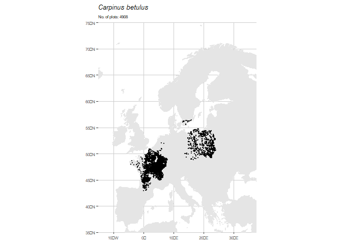

```r
# Species distribution plot

ggplot() +
  geom_spatvector(data = border_spat2, fill = "grey90", color = "grey90") +
  geom_spatvector(data = sp_v, color = "black",size = .05, alpha = .7) +
  coord_sf(xlim = c(-15, 37.5), ylim = c(35, 75), expand = FALSE) +
  labs(title = unique(sp$species.cor),
       subtitle = paste0("No. of plots: ", nrow(sp))) +
  theme(
    panel.background = element_rect(fill = "white"),
    panel.grid.major = element_line(color = "grey80"),
    axis.text = element_text(size = 6),
    title = element_text(size = 8),
    axis.title = element_text(size = 7),
    plot.title = element_text(face = "italic"),
    plot.subtitle = element_text(size = 6)
  )
```

## 3.2. Explanatory variables

### 3.2.1. Distribution

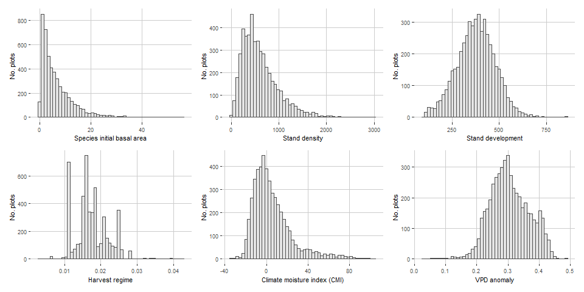

```r
# Names of the explanatory variables

var_names <- c("ba.ha_sp", "density.ha", "mean_dbh_large", "ba_perc_HARVEST", "cmi_clim", "vpd_gs_anomaly")

# Labels for the graphics

var_labels <- c("Species initial basal area", "Stand density", "Stand development", "Harvest regime", "Climate moisture index (CMI)", "VPD anomaly")

hists <- purrr::map2(
  var_names, var_labels, \(x, y)
  ggplot() +
    geom_histogram(aes(x = sp[[x]], #fill = ..count.. #des-comment for fun :)
      ),  fill = "gray90", color = "gray30",
      bins = 50) +
    # scale_fill_viridis(option = "F", end = .85) + #des-comment for fun :)
    labs(x = y, y = "No. plots") +
    theme(
      legend.position = "none",
      panel.background = element_rect(fill = "white"),
      panel.grid.major = element_line(color = "grey80"),
      title = element_text(size = 7.5),
      axis.title = element_text(size = 8),
      axis.text = element_text(size = 7)
    )
)

patchwork::wrap_plots(hists)+
  plot_layout(nrow = 2, ncol = 3)
```

### 3.2.2. Correlations

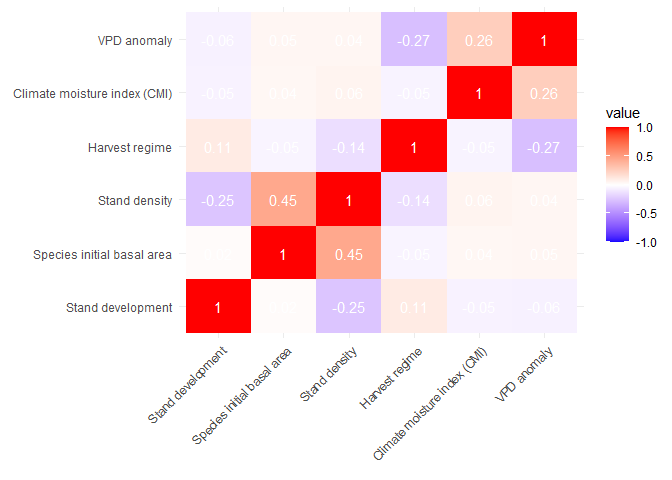

```r
# Creating the correlation matrix for the explanatory variables

cor_mat_str <- cor(sp[,c(
  "mean_dbh_large",
  "ba.ha_spcm",
  "density.ha",
  "ba_perc_HARVEST",
  "cmi_clim",
  "vpd_gs_anomaly"
)],
use = "complete.obs",
method = "pearson")

cor_mat_melted <- melt(cor_mat_str)

# Change the variables names for the correlation heatmap

var_labels <- rev(c("VPD anomaly", "Climate moisture index (CMI)", "Harvest regime", "Stand density", "Species initial basal area", "Stand development"))
cor_mat_melted$Var1 <- factor(cor_mat_melted$Var1, labels = var_labels)
cor_mat_melted$Var2 <- factor(cor_mat_melted$Var2, labels = var_labels)

# Plot the correlation heatmap

ggplot(data = cor_mat_melted, aes(x = Var1, y = Var2, fill = value, label = round(value, 2))) +
  geom_tile() +
  geom_text(color = "white") +
  scale_fill_gradient2(low = "blue", mid = "white", high = "red",
                       midpoint = 0, limits = c(-1, 1)) +
  theme_minimal() +
  theme(axis.text.x = element_text(angle = 45, hjust = 1)) +
  labs(y = element_blank(), x = element_blank())
```

## 3.3. Response variables

### 3.3.1. Distribution

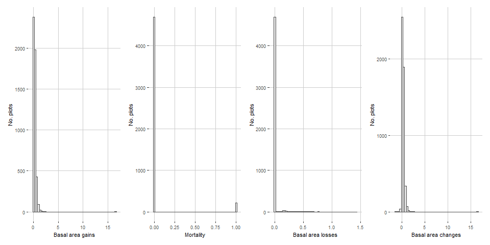

```r
var_names <- c("ba.gain_year" , "mortality", "ba.loss_year", "ba.change.dif_year")

var_labels <- c("Basal area gains", "Mortality", "Basal area losses", "Basal area changes")

hists <- purrr::map2(
  var_names, var_labels, \(x, y)
  ggplot() +
    geom_histogram(aes(x = sp[[x]], #fill = ..count.. #des-comment for fun :)
      ),  fill = "gray90", color = "gray30",
      bins = 50) +
    # scale_fill_viridis(option = "F", end = .85) + #des-comment for fun :)
    labs(x = y, y = "No. plots") +
    theme(
      legend.position = "none",
      panel.background = element_rect(fill = "white"),
      panel.grid.major = element_line(color = "grey80"),
      title = element_text(size = 7.5),
      axis.title = element_text(size = 8),
      axis.text = element_text(size = 7)
    )
)

patchwork::wrap_plots(hists)+
  plot_layout(nrow = 1, ncol = 4)
```

# 4. Species-specific models

## 4.1. Basal area gains model

GAM model for growth using the gam function from the mgcv package. We transformed some of the variables when it led to an improvement in R-squared.

```r
gains_mod <-
  gam(log(ba.gain_yearcm) ~
        log(ba.ha_spcm) + log(density.ha) + ba_perc_HARVEST + country +
        te(cmi_clim, vpd_gs_anomaly, mean_dbh_large, bs = "cr"), # we include the interaction term inside a smooth function
      family = "gaussian", # we use the gaussian famlily because growth is expected to have a Right-Skewed distribution
      data = sp,
      method = "REML")
```

The summary function gives us the parameters, the significance of the parameters and the smooth term (interaction) and the explained variance

```r
summary(gains_mod)
```

```
##
## Family: gaussian
## Link function: identity
##
## Formula:
## log(ba.gain_yearcm) ~ log(ba.ha_spcm) + log(density.ha) + ba_perc_HARVEST +
##     country + te(cmi_clim, vpd_gs_anomaly, mean_dbh_large, bs = "cr")
##
## Parametric coefficients:
##                       Estimate Std. Error t value Pr(>|t|)
## (Intercept)            1.22107    0.24472   4.990 6.26e-07 ***
## log(ba.ha_spcm)        0.59065    0.01332  44.339  < 2e-16 ***
## log(density.ha)        0.03049    0.01973   1.546 0.122276
## ba_perc_HARVEST        6.00447    3.05520   1.965 0.049433 *
## countryCzech Republic -1.09555    0.25946  -4.222 2.46e-05 ***
## countryFrance         -0.43017    0.18730  -2.297 0.021678 *
## countryNetherlands    -0.75293    0.42470  -1.773 0.076317 .
## countryPoland         -0.66904    0.18915  -3.537 0.000408 ***
## countrySweden         -0.84298    0.30927  -2.726 0.006439 **
## ---
## Signif. codes:  0 '***' 0.001 '**' 0.01 '*' 0.05 '.' 0.1 ' ' 1
##
## Approximate significance of smooth terms:
##                                              edf Ref.df     F
## te(cmi_clim,vpd_gs_anomaly,mean_dbh_large) 19.11  23.69 30.07
##                                            p-value
## te(cmi_clim,vpd_gs_anomaly,mean_dbh_large)  <2e-16 ***
## ---
## Signif. codes:  0 '***' 0.001 '**' 0.01 '*' 0.05 '.' 0.1 ' ' 1
##
## R-sq.(adj) =  0.391   Deviance explained = 39.4%
## -REML = 6182.2  Scale est. = 0.72353   n = 4908
```

```r
gains_mod$aic
```

```
## [1] 12370.05
```

#### - Model testing and Comprobations

We used the packages “gratia” and “DHARMa” to visualize the residuals

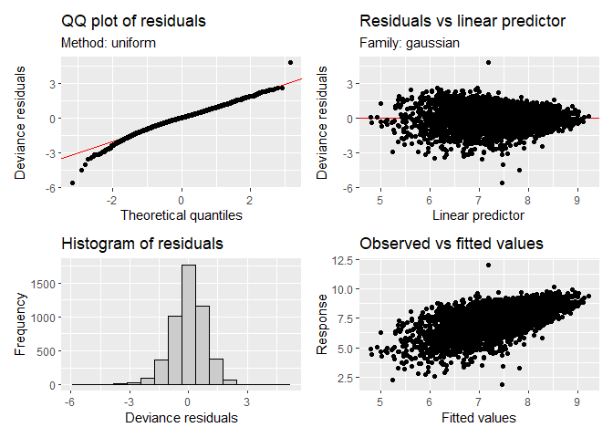

```r
gratia::appraise(gains_mod)
```

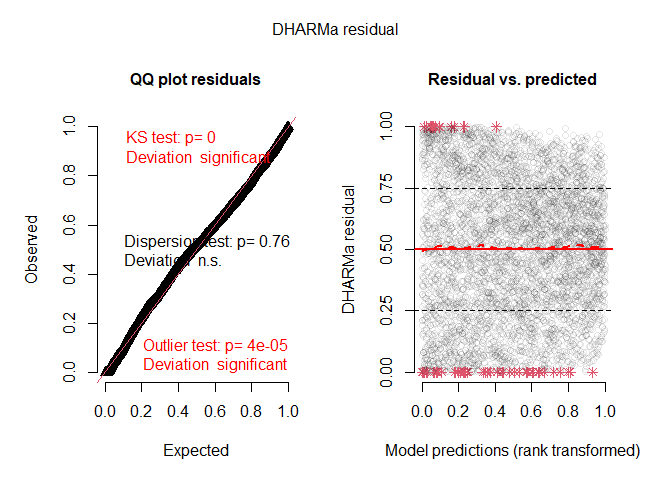

```r
res <- DHARMa::simulateResiduals(gains_mod, integerResponse = TRUE)
plot(res)
```

#### - Cross-validation

The cross validation was calculated to evaluate de predictive ability of the models.

```r
# This is the number of repetitions that the test sub sample will be validated with the trained model
n_repes <- 10
# Train is a random subsample of 80% of the data
cv <- modelr::crossv_mc(sp, test = .2, n = n_repes)

crossval_g <- function(x){
  # x is the number of the repetition (n_repes)

  ### Select train and test #
  # train just for fit the model
  train <- as_tibble(cv$train[[x]])
  # test to predict
  test <- as_tibble(cv$test[[x]])

  ### Error: country levels on train-test are different #
  # in some cases, it depends on the random subsample.
  # I filter by the common countries in both datasets.
  # Only a few rows are lost
  common_country <-
    intersect(unique(train$country), unique(test$country))

  test_filtered <- test |>
    filter(country %in% common_country)

  train_filtered <- train |>
    filter(country %in% common_country)

  # model with train
  gam.model <-
    gam(log(ba.gain_yearcm) ~
        log(ba.ha_spcm) +
          log(density.ha) +
          ba_perc_HARVEST +
          country +
          te(cmi_clim, vpd_gs_anomaly, mean_dbh_large, bs = "cr"),
        family = "gaussian",
        data = train_filtered,
        method = "REML")

  # results with modelr
  results <- tibble(
    mean_gains = mean(log(train_filtered$ba.gain_yearcm)),
    # Higher, better:
    r2 = modelr::rsquare(gam.model, data = test_filtered),
    # Lower, better:
    rmse = modelr::rmse(gam.model, data = test_filtered),
    nrmse = rmse / mean_gains,
    # Lower, better
    mae = modelr::mae(gam.model, data = test_filtered),
    nmae = mae / mean_gains,
    # To see the consequences of the country filter
    test_row = nrow(test_filtered),
    train_row = nrow(train_filtered)

  )

  return(results)
}

# Run SAFELY. Evita que la iteración se pare con cualquier fallo
cv_results_g <-
  seq_len(n_repes) |>
  purrr::map(
    purrr::safely(
      crossval_g,
      otherwise = "Error"
    )
  )

# Results all repetitions
results_df_g <-
  seq_len(n_repes) |>
  purrr::map_df(
    \(x) {

      result <- cv_results_g[[x]][["result"]]

      if (is.data.frame(result)) {
        return(result)
      } else {
        return(tibble())
      }

    }
  )

# Final result
cv_gains <-
  results_df_g |>
  dplyr::summarise(
    R2 = mean(r2),
    sd_R2 = sd(r2),
    RMSE = mean(rmse),
    sd_RMSE = sd(rmse),
    NRMSE = mean(nrmse),
    sd_NRMSE = sd(nrmse),
    MAE = mean(mae),
    sd_MAE = sd(mae),
    NMAE = mean(nmae),
    sd_NMAE = sd(nmae)
  )

print(cv_gains)
```

```
## # A tibble: 1 × 10
##      R2  sd_R2  RMSE sd_RMSE NRMSE sd_NRMSE   MAE sd_MAE   NMAE
##   <dbl>  <dbl> <dbl>   <dbl> <dbl>    <dbl> <dbl>  <dbl>  <dbl>
## 1 0.378 0.0234 0.851  0.0132 0.116  0.00178 0.651 0.0102 0.0889
## # ℹ 1 more variable: sd_NMAE <dbl>
```

## 4.2. Basal area losses models

For the basal area losses we built two different types of models since the losses variable has a lot of ceros for the plots in which there was no mortality between the measurements.

We modeled the probability of mortality (as a binomial variable for presence or absence or mortality 0/1) separately from the actual basal area losses for when there was mortality in the plot.

### 4.2.1. Probability of mortality model

```r
mortality_mod <- gam(mortality ~
            ba.ha_spcm + density.ha + ba_perc_HARVEST + country +
            te(cmi_clim, vpd_gs_anomaly, mean_dbh_large, bs = "cr"),
          family = "binomial",
          data = sp,
          method = "REML")
```

The summary function gives us the parameters, the significance of the parameters and the smooth term (interaction) and the explained variance

```r
summary(mortality_mod)
```

```
##
## Family: binomial
## Link function: logit
##
## Formula:
## mortality ~ ba.ha_spcm + density.ha + ba_perc_HARVEST + country +
##     te(cmi_clim, vpd_gs_anomaly, mean_dbh_large, bs = "cr")
##
## Parametric coefficients:
##                         Estimate Std. Error z value Pr(>|z|)
## (Intercept)           -3.822e+01  1.000e+07   0.000    1.000
## ba.ha_spcm             9.272e-06  1.040e-06   8.917   <2e-16 ***
## density.ha             4.908e-04  2.057e-04   2.387    0.017 *
## ba_perc_HARVEST       -4.738e+00  1.846e+01  -0.257    0.797
## countryCzech Republic -9.267e-01  1.696e+07   0.000    1.000
## countryFrance          3.375e+01  1.000e+07   0.000    1.000
## countryNetherlands     0.000e+00  0.000e+00     NaN      NaN
## countryPoland          3.474e+01  1.000e+07   0.000    1.000
## countrySweden          0.000e+00  0.000e+00     NaN      NaN
## ---
## Signif. codes:  0 '***' 0.001 '**' 0.01 '*' 0.05 '.' 0.1 ' ' 1
##
## Approximate significance of smooth terms:
##                                              edf Ref.df Chi.sq
## te(cmi_clim,vpd_gs_anomaly,mean_dbh_large) 24.42  28.88  70.22
##                                             p-value
## te(cmi_clim,vpd_gs_anomaly,mean_dbh_large) 2.73e-05 ***
## ---
## Signif. codes:  0 '***' 0.001 '**' 0.01 '*' 0.05 '.' 0.1 ' ' 1
##
## Rank: 131/133
## R-sq.(adj) =  0.0633   Deviance explained = 13.7%
## -REML = 727.01  Scale est. = 1         n = 4908
```

```r
mortality_mod$aic
```

```
## [1] 1597.037
```

#### - Model testing and comprobations

We used the packages “gratia” and “DHARMa” to visualize the residuals

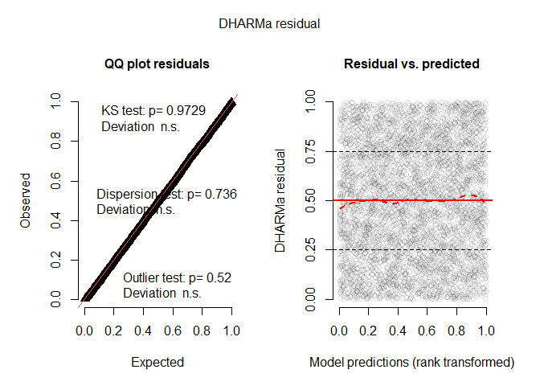

```r
res <- DHARMa::simulateResiduals(mortality_mod, integerResponse = TRUE)
plot(res)
```

#### - Cross-validation

The cross validation was calculated to evaluate de predictive ability of the models.

```r
## Number of repetitions #
# This is the number of repetitions that the test
# sub sample will be validated with the trained model
n_repes <- 10

## Split the data #
# Train is a random subsample of 80% of the data
cv <- modelr::crossv_mc(sp, test = .2, n = n_repes)

crossval_b <- function(x){
  # x is the number of the repetition (n_repes)

  ### Select train and test #
  # train just for fit the model
  train <- as_tibble(cv$train[[x]])
  # test to predict
  test <- as_tibble(cv$test[[x]])

  ### Error: country levels on train-test are different #
  # in some cases, it depends on the random subsample.
  # I filter by the common countries in both datasets.
  # Only a few rows are lost
  common_country <-
    intersect(unique(train$country), unique(test$country))

  test_filtered <- test |>
    filter(country %in% common_country) |>
    mutate(mortality = as.factor(mortality))

  train_filtered <- train |>
    filter(country %in% common_country) |>
    mutate(mortality = as.factor(mortality))

  ### Model with train #
  binomial.losses <-
    gam(
      mortality ~
        ba.ha_spcm +
        ba_perc_HARVEST +
        country +
        te(cmi_clim, vpd_gs_anomaly, mean_dbh_large, bs = "cr"),
      #weights = density.ha,
      family = "binomial",
      data = train_filtered,
      method = "REML"
    )

  ### Predictions with test #
  predictions <-
    predict(binomial.losses,
            type = "response",
            newdata = test_filtered,
    )

  ### Results accuracy #
  # create a confusion matrix with thershold value = 0.5
  results_acc <-
    tibble(
      obs = test_filtered$mortality,
      preds = case_when(
        predictions >= 0.5 ~ 1,
        T ~ 0
      )
    ) |>
    mutate(across(everything(), as.factor))

  # calculate accuracy and kappa with caret package
  conf <- caret::confusionMatrix(
    data = results_acc$obs,
    reference = results_acc$preds,
    positive = "0")

  ### Results
  results <- tibble(
    accuracy = conf[["overall"]][["Accuracy"]],
    kappa = conf[["overall"]][["Kappa"]],
    test_row = nrow(test_filtered),
    train_row = nrow(train_filtered)

  )

  return(results)


}

# Run SAFELY
cv_results_b <-
  seq_len(n_repes) |>
  purrr::map(
    purrr::safely(
      crossval_b,
      otherwise = "Error"
    )
  )
```

[output not shown]

```r
# Results all repetitions #
results_df_b <-
    seq_len(n_repes) |>
    purrr::map_df(
      \(x) {

        result <- cv_results_b[[x]][["result"]]

        if (is.data.frame(result)) {
          return(result)
        } else {
          return(tibble())
        }

      }
    )

# Final results #
results_df_b |>
  summarise(
    ACC = mean(accuracy),
    sd_ACC = sd(accuracy),
    KAPPA = mean(kappa),
    sd_K = sd(kappa)
  )
```

```
## # A tibble: 1 × 4
##     ACC  sd_ACC  KAPPA   sd_K
##   <dbl>   <dbl>  <dbl>  <dbl>
## 1 0.953 0.00687 0.0317 0.0381
```

### 4.2.2. Loss model

```r
loss_mod <- gam(log(ba.loss_yearcm) ~
            log(ba.ha_spcm) + log(density.ha) + ba_perc_HARVEST + country +
            te(cmi_clim, vpd_gs_anomaly, mean_dbh_large, bs = "cr"),
          family = "gaussian",
          data = loss,
          method = "REML")
```

The summary function gives us the parameters, the significance of the parameters and the smooth term (interaction) and the explained variance

```r
summary(loss_mod)
```

```
##
## Family: gaussian
## Link function: identity
##
## Formula:
## log(ba.loss_yearcm) ~ log(ba.ha_spcm) + log(density.ha) + ba_perc_HARVEST +
##     country + te(cmi_clim, vpd_gs_anomaly, mean_dbh_large, bs = "cr")
##
## Parametric coefficients:
##                 Estimate Std. Error t value Pr(>|t|)
## (Intercept)      7.30142    0.76077   9.597  < 2e-16 ***
## log(ba.ha_spcm)  0.20678    0.07274   2.843  0.00493 **
## log(density.ha) -0.25434    0.09210  -2.761  0.00628 **
## ba_perc_HARVEST -6.72753    9.26486  -0.726  0.46859
## countryPoland   -0.70901    0.11981  -5.918 1.37e-08 ***
## ---
## Signif. codes:  0 '***' 0.001 '**' 0.01 '*' 0.05 '.' 0.1 ' ' 1
##
## Approximate significance of smooth terms:
##                                              edf Ref.df     F
## te(cmi_clim,vpd_gs_anomaly,mean_dbh_large) 9.041   10.2 2.638
##                                            p-value
## te(cmi_clim,vpd_gs_anomaly,mean_dbh_large) 0.00415 **
## ---
## Signif. codes:  0 '***' 0.001 '**' 0.01 '*' 0.05 '.' 0.1 ' ' 1
##
## R-sq.(adj) =  0.338   Deviance explained = 37.8%
## -REML = 179.01  Scale est. = 0.33209   n = 217
```

```r
loss_mod$aic
```

```
## [1] 392.1764
```

#### - Model testing and comprobations

We used the packages “gratia” and “DHARMa” to visualize the residuals

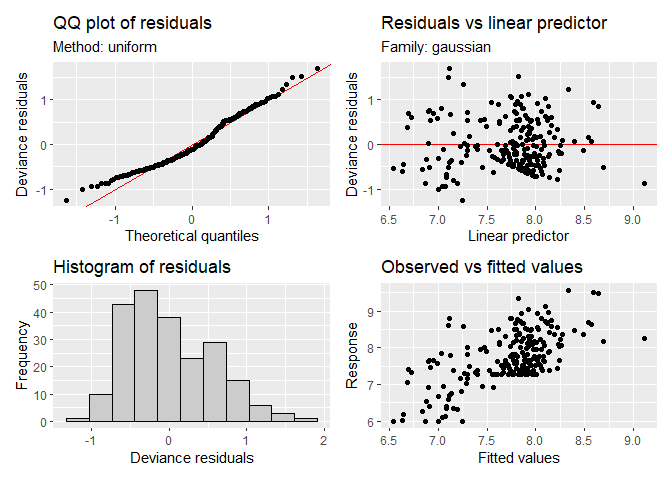

```r
gratia::appraise(loss_mod)
```

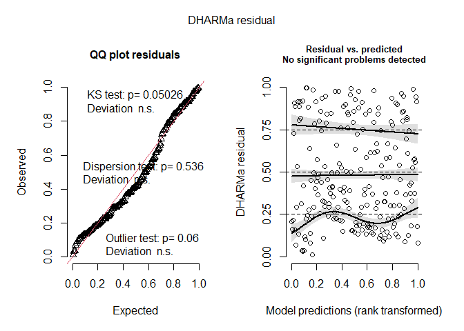

```r
res <- DHARMa::simulateResiduals(loss_mod, integerResponse = TRUE)
plot(res)
```

#### - Cross-validation

The cross validation was calculated to evaluate de predictive ability of the models.

```r
## Number of repetitions #
# This is the number of repetitions that the test sub sample will be validated
# with the trained model
n_repes <- 10

## Split the data ####
# Train is a random subsample of 80% of the data
cv <- modelr::crossv_mc(loss, test = .2, n = n_repes)

crossval_l <- function(x){
  # x is the number of the repetition (n_repes)

  ### Select train and test #
  # train just for fit the model
  train <- as_tibble(cv$train[[x]])
  # test to predict
  test <- as_tibble(cv$test[[x]])

  ### Error: country levels on train-test are different #
  # in some cases, it depends on the random subsample.
  # I filter by the common countries in both datasets.
  # Only a few rows are lost
  common_country <-
    intersect(unique(train$country), unique(test$country))

  test_filtered <- test |>
    filter(country %in% common_country)

  train_filtered <- train |>
    filter(country %in% common_country)

  ### Modelo gam #
  gam.model.loss <-
    gam(log(ba.loss_yearcm) ~
            log(ba.ha_spcm) +
          log(density.ha) +
          ba_perc_HARVEST +
          country +
            te(cmi_clim, vpd_gs_anomaly, mean_dbh_large, bs = "cr"),
          family = "gaussian",
          data = train_filtered,
          method = "REML")

  ### Results: metrics with modelr package #
  results <- tibble(
    mean_losses = mean(log(train_filtered$ba.loss_yearcm)),
    # Higher, better:
    r2 = modelr::rsquare(gam.model.loss, data = test_filtered),
    # Lower, better:
    rmse = modelr::rmse(gam.model.loss, data = test_filtered),
    nrmse = rmse / mean_losses,
    # Lower, better
    mae = modelr::mae(gam.model.loss, data = test_filtered),
    nmae = mae / mean_losses,
    # To see the consequences of the country filter
    test_row = nrow(test_filtered),
    train_row = nrow(train_filtered)

  )

  return(results)


}

# Run SAFELY
cv_results_l <-
  seq(1:n_repes) |>
  purrr::map(
    purrr::safely(
      crossval_l,
      otherwise = "Error"
    )
  )

# Results all repetitions #
results_df_l <-
  seq_len(n_repes) |>
  purrr::map_df(
    \(x) {

      result <- cv_results_l[[x]][["result"]]

      if (is.data.frame(result)) {
        return(result)
      } else {
        return(tibble())
      }

    }
  )

# Final result #
results_df_l |>
  summarise(
    R2 = mean(r2),
    sd_R2 = sd(r2),
    RMSE = mean(rmse),
    sd_RMSE = sd(rmse),
    NRMSE = mean(nrmse),
    sd_NRMSE = sd(nrmse),
    MAE = mean(mae),
    sd_MAE = sd(mae),
    NMAE = mean(nmae),
    sd_NMAE = sd(nmae)
  )
```

```
## # A tibble: 1 × 10
##      R2 sd_R2  RMSE sd_RMSE  NRMSE sd_NRMSE   MAE sd_MAE   NMAE
##   <dbl> <dbl> <dbl>   <dbl>  <dbl>    <dbl> <dbl>  <dbl>  <dbl>
## 1 0.176 0.175 0.613  0.0615 0.0793  0.00803 0.496 0.0501 0.0641
## # ℹ 1 more variable: sd_NMAE <dbl>
```

## 4.3. Basal area changes model

```r
change_mod <-
  gam(ba.change.dif_yearcm ~
      log(ba.ha_spcm) + log(density.ha) + ba_perc_HARVEST + country +
        te(cmi_clim, vpd_gs_anomaly, mean_dbh_large, bs = "cr"),
      family = "gaussian",
      data = sp,
      method = "REML")
```

The summary function gives us the parameters, the significance of the parameters and the smooth term (interaction) and the explained variance

```r
summary(change_mod)
```

```
##
## Family: gaussian
## Link function: identity
##
## Formula:
## ba.change.dif_yearcm ~ log(ba.ha_spcm) + log(density.ha) + ba_perc_HARVEST +
##     country + te(cmi_clim, vpd_gs_anomaly, mean_dbh_large, bs = "cr")
##
## Parametric coefficients:
##                       Estimate Std. Error t value Pr(>|t|)
## (Intercept)           -7611.13     893.35  -8.520  < 2e-16 ***
## log(ba.ha_spcm)         854.81      48.89  17.483  < 2e-16 ***
## log(density.ha)         297.58      72.37   4.112 3.99e-05 ***
## ba_perc_HARVEST        3983.52   11126.00   0.358   0.7203
## countryCzech Republic -2060.47     942.05  -2.187   0.0288 *
## countryFrance          -985.82     680.19  -1.449   0.1473
## countryNetherlands    -1454.83    1556.39  -0.935   0.3500
## countryPoland         -1446.64     687.15  -2.105   0.0353 *
## countrySweden         -2059.24    1008.92  -2.041   0.0413 *
## ---
## Signif. codes:  0 '***' 0.001 '**' 0.01 '*' 0.05 '.' 0.1 ' ' 1
##
## Approximate significance of smooth terms:
##                                              edf Ref.df     F
## te(cmi_clim,vpd_gs_anomaly,mean_dbh_large) 11.77  13.53 21.44
##                                            p-value
## te(cmi_clim,vpd_gs_anomaly,mean_dbh_large)  <2e-16 ***
## ---
## Signif. codes:  0 '***' 0.001 '**' 0.01 '*' 0.05 '.' 0.1 ' ' 1
##
## R-sq.(adj) =  0.127   Deviance explained = 13.1%
## -REML =  46337  Scale est. = 9.7759e+06  n = 4908
```

```r
change_mod$aic
```

```
## [1] 92947.4
```

#### - Model testing and comprobations

We used the packages “gratia” and “DHARMa” to visualize the residuals

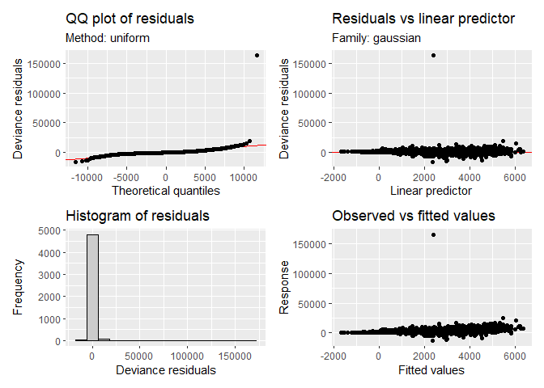

```r
gratia::appraise(change_mod)
```

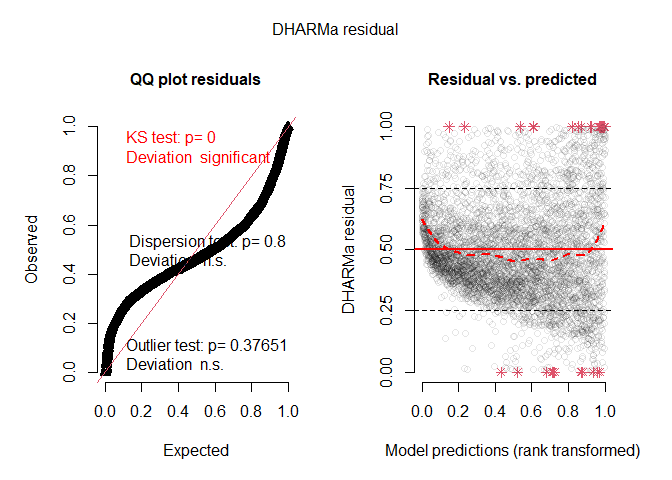

```r
res <- DHARMa::simulateResiduals(change_mod, integerResponse = TRUE)
plot(res)
```

#### - Cross-validation

The cross validation was calculated to evaluate de predictive ability of the models.

```r
# This is the number of repetitions that the test sub sample will be validated with the trained model
n_repes <- 10
# Train is a random subsample of 80% of the data
cv <- modelr::crossv_mc(sp, test = .2, n = n_repes)

crossval_c <- function(x){
  # x is the number of the repetition (n_repes)

  ### Select train and test #
  # train just for fit the model
  train <- as_tibble(cv$train[[x]])
  # test to predict
  test <- as_tibble(cv$test[[x]])

  ### Error: country levels on train-test are different #
  # in some cases, it depends on the random subsample.
  # I filter by the common countries in both datasets.
  # Only a few rows are lost
  common_country <-
    intersect(unique(train$country), unique(test$country))

  test_filtered <- test |>
    filter(country %in% common_country)

  train_filtered <- train |>
    filter(country %in% common_country)

  # model with train
  gam.model <- #change
      gam(ba.change.dif_yearcm ~
            ba.ha_spcm +
            density.ha +
            ba_perc_HARVEST +
            country +
            te(cmi_clim, vpd_gs_anomaly, mean_dbh_large, bs = "cr"),
          family = "gaussian",
          data = train_filtered, # !
          method = "REML")

  # results with modelr
  results <- tibble(
    mean_change = mean(train_filtered$ba.change.dif_yearcm,
                      na.rm = TRUE),
    # Higher, better:
    r2 = modelr::rsquare(gam.model, data = test_filtered),
    # Lower, better:
    rmse = modelr::rmse(gam.model, data = test_filtered),
    nrmse = rmse / mean_change,
    # Lower, better
    mae = modelr::mae(gam.model, data = test_filtered),
    nmae = mae / mean_change,
    # To see the consequences of the country filter
    test_row = nrow(test_filtered),
    train_row = nrow(train_filtered)

  )

  return(results)

}

# Run SAFELY. Evita que la iteración se pare con cualquier fallo
cv_results_c <-
  seq_len(n_repes) |>
  purrr::map(
    purrr::safely(
      crossval_c,
      otherwise = "Error"
    )
  )

# Results all repetitions
results_df_c <-
  seq_len(n_repes) |>
  purrr::map_df(
    \(x) {

      result <- cv_results_c[[x]][["result"]]

      if (is.data.frame(result)) {
        return(result)
      } else {
        return(tibble())
      }

    }
  )

# Final result
results_df_c |>
    summarise(
      R2 = mean(r2),
      sd_R2 = sd(r2),
      RMSE = mean(rmse),
      sd_RMSE = sd(rmse),
      NRMSE = mean(nrmse),
      sd_NRMSE = sd(nrmse),
      MAE = mean(mae),
      sd_MAE = sd(mae),
      NMAE = mean(nmae),
      sd_NMAE = sd(nmae)
    )
```

```
## # A tibble: 1 × 10
##      R2  sd_R2  RMSE sd_RMSE NRMSE sd_NRMSE   MAE sd_MAE  NMAE
##   <dbl>  <dbl> <dbl>   <dbl> <dbl>    <dbl> <dbl>  <dbl> <dbl>
## 1 0.207 0.0933 2789.   1497.  1.20    0.657 1429.   66.7 0.615
## # ℹ 1 more variable: sd_NMAE <dbl>
```

# 5. Predictions

We calculated predictions for each species with the four models and mapped them across Europe.

```r
# Calculate predictions with predict fuction.

pred_gains <- predict(gains_mod, newdata = sp, type = "response")
pred_mort <- predict(mortality_mod, newdata = sp, type = "response")
pred_changes <- predict(change_mod, newdata = sp, type = "response")

new_countries <- unique(loss$country)
sp_new_losses <- sp |>
  filter(country %in% new_countries)

pred_losses <- predict(loss_mod, newdata = sp_new_losses, type = "response")

# Add prediction variables to the database

sp$ba.gain.pred_year <- exp(pred_gains)/10000
sp$ba.mort.pred <- pred_mort
sp$ba.change.dif.pred_year <- pred_changes/10000

sp_new_losses$ba.loss.pred_year <- exp(pred_losses)/10000

sp <- sp |>
  left_join(sp_new_losses)
```

```r
# Function to create the map for each demographic variable.

create_maps <- function(var_name, var_title) {

  # Keeping just the values inside quantiles 5 and 95 to leave out outlayers

  q5 <- quantile(sp[var_name], probs = 0.05, na.rm = T)
  q95 <- quantile(sp[var_name], probs = 0.95, na.rm = T)

  sp_data1 <- sp[!(sp[var_name] < q5),]
  sp_data <- sp_data1[!(sp_data1[var_name] > q95),]

  # Base Europe map
  border <- map_data(map = "world")

  border2 <- border |>
    mutate(coords = paste(long, lat, sep = " ")) |>
    group_by(group, region) |>
    dplyr::summarize(polygon = str_c(coords, collapse = ", "))

  create_vect <- function(group_n) {
    vect(paste0("POLYGON ((", border2[border2$group == group_n, "polygon"], "))"),
         crs = "EPSG:4326")
  }

  border_spat <-
    map(seq_along(seq_along(border2$group)), \(x) create_vect(x))

  border_spat2 <- vect(
    x = border_spat,
    crs = "EPSG:4326"
  )

  # Data
  dat_df<- terra::vect(
    x = sp_data,
    geom = c("longitude", "latitude"),
    crs = "EPSG:4326"
  )

  dat_df_df <- as.data.frame(dat_df)
  col_data <- as.numeric(dat_df_df[[var_name]])

  # Map

  plot <- ggplot() +
    geom_spatvector(
      data = border_spat2,
      fill = "grey90",
      color = "grey90"
    ) +
    geom_spatvector(
      data = dat_df,
      aes(color = col_data),
      size = .05,
      alpha = .7
    ) +
    scale_color_viridis_c(
      bquote(.(var_title) ~ paste("(", m^2, ha^-1, yr^-1,")"))
    ) +
    coord_sf(
      xlim = c(-15, 37.5),
      ylim = c(35, 75),
      expand = FALSE
    ) +
    labs(
        title = var_title
    ) +
    theme(
      panel.background = element_rect(fill = "white"),
      panel.grid.major = element_line(color = "grey80"),
      axis.text = element_text(size = 6),
      title = element_text(size = 8),
      axis.title = element_text(size = 7),
      plot.title = element_text(size = 6)
    )

  return(plot)
}

variables <- c("ba.gain.pred_year", "ba.change.dif.pred_year", "ba.mort.pred",    "ba.loss.pred_year")

labels <- c("Basal area gains", "Basal area changes", "Probability of mortality", "Basal area losses")

maps <-
  furrr::future_map2(
    variables,
    labels,
    \(x, y) create_maps(x, y))
names(maps) <- c("gains", "changes", "mortality", "losses")

gains <- maps$gains
mortality <- maps$mortality
losses <- maps$losses
changes <- maps$changes
```

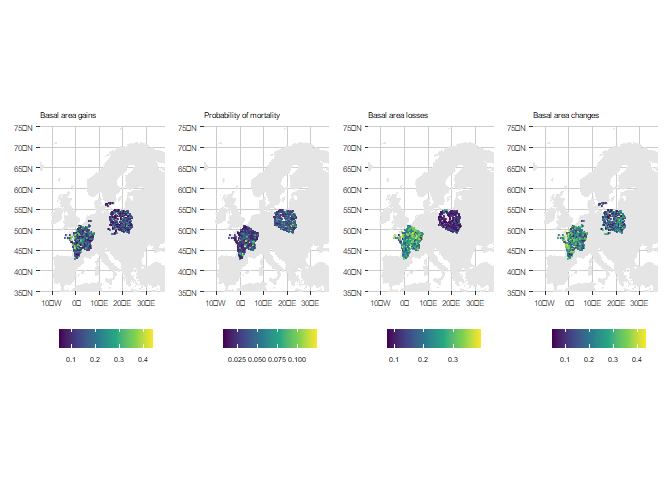

```r
  (gains | mortality | losses | changes)  +
  plot_layout(nrow = 1, ncol = 4) +
  plot_layout(guides = "keep") &
  theme(legend.position = "bottom",
        legend.direction = "horizontal",
        legend.key.height = unit(0.5, "cm"),
        legend.key.width = unit(0.5, "cm"),
        legend.text = element_text(size = 5),
        legend.title = element_blank())
```